# Web Scraping with `{rvest}`

Data Aquisition and Distribution

Dr Zak Varty

## Aquiring Data by Web Scraping

The data you need will not always be delivered to you, sometimes you have to go out and get it for yourself.

- *Web scraping* is one common way to obtain this data
- *APIs* are another common way to both obtain and distribute data

This video we will focus of the former: extracting data from a HTML webpage.

# 1. What is a webpage?

## What is a webpage?

Like with LaTeX, content and presentation are handled separately. With webpages, this separation is even more extreme.

- *HyperText Markup Language* (HTML) files store content of a webpage.
- *Cascading Style Sheet* (CSS) files describe how that content should be displayed.

## A Basic HTML page - Code

```html
<html>
<head>
  <title>Page title</title>
</head>
<body>
  <h1 id='first'>A level 1 heading</h1>
  <p>Hello World!</p>
  <p>Here is some plain text &amp; <b>some bold text.</b></p>
  <img src='myimg.png' width='100' height='100'>
</body>
```

## A Basic HMTL Page - In Browser

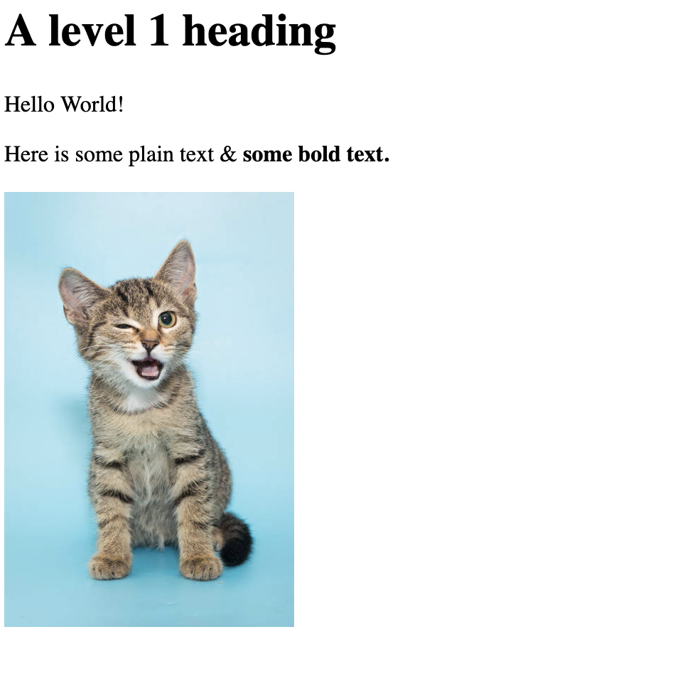

[CSS Zen Garden](http://www.csszengarden.com/) - multiple CSS files formatting the same HTML.

## A Basic HTML Page - Structure

```html
<html>
<head>
  <title>Page title</title>
</head>
<body>
  <h1 id='first'>A level 1 heading</h1>
  <p>Hello World!</p>
  <p>Here is some plain text &amp; <b>some bold text.</b></p>
  <img src='myimg.png' width='100' height='100'>
</body>
```

- Escape characters: > is `&gt;`, < is `&lt;`, & is `&amp;`, …

## Important HTML Elements

- The `<html>` element must enclose every HTML page:
  - `<head>` element contains metadata,
  - `<body>` element contains content displayed in browser.
- Block elements: headers `<h1>`, …, `<h6>`, paragraphs `<p>`, lists `<ol>` & `<ul>`.
- Inline elements: bold `<b>`, italic `<i>`, emphasis `<em>`, hyperlinks `<a>`.

Resources: [MDN Web Docs](https://developer.mozilla.org/en-US/docs/Web/HTML) & [W3schools website](https://www.w3schools.com/html/default.asp).

## HTML Attributes

HTML attributes are contained within the opening tag.

```html
<tag attribute1='value1' attribute2='value2'>element contents</tag>
```

- `id` and `class` attributes are usually the most important in relation to web scraping.

## CSS Selectors

- CSS has it’s own system for selecting elements of a webpage: **selectors**.

CSS Selectors can work on the level of an element type, a class, or a tag and these can be used in a nested (or *cascading*) way.

- The `p` selector will select all paragraph `<p>` elements.
- The `.title` selector will select all elements with class `“title”`.
- The `p.special` selector will select all`<p>` elements with class `“special”`.
- The `#title` selector will select the element with the id attribute `“title”`.

## Which Attributes and Selectors Do You Need?

Before you can scrape data, you first need to be able to describe what you want to scrape!

- right click + “inspect page source” (F12)
- right click + “inspect”
- Rvest [Selector Gadget](https://rvest.tidyverse.org/articles/selectorgadget.html) (very useful but fallible)

Start simple and build your confidence. Dynamic webpages can be more difficult.

# 2. Reading HTML with `{rvest}`

[figure not shown]

## Reading HTML with `{rvest}`

`{rvest}` gives us funcitonality just like `{readr}`.

```r
html <- rvest::read_html("https://www.zakvarty.com/professional/teaching.html")
class(html)
```

```
[1] "xml_document" "xml_node"
```

Rather than a `tibble` we get an `xml_document`, an object from `{xml2}`.

```r
html
```

```
{html_document}
<html xmlns="http://www.w3.org/1999/xhtml" lang="en" xml:lang="en">
[1] <head>\n<meta http-equiv="Content-Type" content="text/html; charset=UTF-8 ...
[2] <body class="nav-fixed">\n\n<div id="quarto-search-results"></div>\n  <he ...
```

## Extracting HTML elements

```r
library(rvest)
html %>% html_element("h1")
## {html_node}
## <h1>
html %>% html_elements("h2")
## {xml_nodeset (2)}
## [1] <h2 id="toc-title">On this page</h2>
## [2] <h2 class="anchored" data-anchor-id="course-history">Course History</h2>
html %>% html_elements("p")
## {xml_nodeset (7)}
## [1] <p>I am fortunate to have had the opportunity to teach in a variety of ro ...
## [2] <p>Developing and teaching a number of modules in statistics, data scienc ...
## [3] <p>Supervising undergraduate, postgraduate and doctoral research projects ...
## [4] <p>Adapting and leading short courses on scientific writing and communica ...
## [5] <p>Running workshops and computer labs for undergraduate and postgraduate ...
## [6] <p>Speaking at univerisity open days and providing one-to-one tuition to  ...
## [7] <p>I am an associate fellow of the Higher Education Academy, which you ca ...
```

```r
html %>% html_elements("p a,h2")
```

```
{xml_nodeset (3)}
[1] <h2 id="toc-title">On this page</h2>
[2] <a href="https://www.advance-he.ac.uk/fellowship/associate-fellowship">he ...
[3] <h2 class="anchored" data-anchor-id="course-history">Course History</h2>
```

## Extracting data from HTML elements

- We have the HTML elements we care about… now what?
- Depends if you are interested in the contents or the attributes of those elements.
- Ideally, someone else will have put everything into a table for you already!

## Extracting text

Extract text using `rvest::html_text()` or `rvest::html_text2()`.

```r
html %>%
  html_elements("#teaching li") %>%
  html_text2()
```

```
[1] "Developing and teaching a number of modules in statistics, data science and data ethics. These were predominantly at the postgradute-level and include courses designed for in-person and remote learning."
[2] "Supervising undergraduate, postgraduate and doctoral research projects."
[3] "Adapting and leading short courses on scientific writing and communication."
[4] "Running workshops and computer labs for undergraduate and postgraduate modules."
[5] "Speaking at univerisity open days and providing one-to-one tuition to high school students."
```

Do you want to extract like the HTML file or like the browser display?

## Extracting Attributes

- Attributes can also contain useful data that you want to extract (links, image sizes, image paths,…).
- Get twitter link from the icon in the footer of the webpage using [Selector Gadget](https://rvest.tidyverse.org/articles/selectorgadget.html).

```r
html %>% html_element(".compact:nth-child(1) .nav-link")
```

```
{html_node}
<a class="nav-link" href="https://www.twitter.com/zakvarty">
[1] <i class="bi bi-twitter" role="img">\n</i>
```

## Extracting Attributes (2)

- Extract the `href` attribute.

```r
html %>%
  html_elements(".compact:nth-child(1) .nav-link") %>%
  html_attr("href")
```

```
[1] "https://www.twitter.com/zakvarty"
```

*Note:* Attributes are always extracted as strings, so may need reformatting before analysis.

## HTML Tables

There are four main elements to know about that make up an HTML table:

- `<table>`,
- `<tr>` (table row),
- `<th>` (table heading),
- `<td>` (table data).

## Example HTML Table

```html
<table>
  <tr>
    <th>Name</th>
    <th>Number</th>
  </tr>
  <tr>
    <td>A</td>
    <td>1</td>
  </tr>
  <tr>
    <td>B</td>
    <td>2</td>
  </tr>
  <tr>
    <td>C</td>
    <td>3</td>
  </tr>
</table>
```

## Extracting HTML Tables

`{rvest}` has a useful function `html_table()` to help us.

```r
html_2 %>%
  html_element("table") %>%
  html_table()
```

```
# A tibble: 3 × 2
  Name  Number
  <chr>  <int>
1 A          1
2 B          2
3 C          3
```

## Extracting HTML Tables (2)

```r
html %>%
  html_element("table") %>%
  html_table()
```

```
# A tibble: 31 × 3
   Year      Course                                     Role
   <chr>     <chr>                                      <chr>
 1 "2022-23" Data Science                               Lecturer
 2 ""        Ethics in Data Science I, II and III       Lecturer
 3 ""        Data Ethics for Digital Chemistry          Lecturer
 4 ""        Y1 research projects: point process models Lecturer
 5 "2021-22" Supervised Learning                        Lecturer
 6 ""        Ethics in Data Science I                   Lecturer
 7 ""        Ethics in Data Science II                  Lecturer
 8 ""        Data Ethics for Digital Chemistry          Lecturer
 9 ""        Y1 research projects: point process models Lecturer
10 "—"       —                                          —
# ℹ 21 more rows
```

## Tip when building tibbles

- Aim: build a tibble with 1 row per observation unit in the HTML (table row, list item, etc).
1. Use `html_elements()` to select the elements that contain each observation unit;
2. Use `html_element()` to extract the variables from each of those observations.

This avoids issues with missing values.

## Tip Example: Star Wars

Example from the [star wars dataset](https://dplyr.tidyverse.org/reference/starwars.html#ref-examples).

```r
starwars_html <- minimal_html("
  <ul>
    <li><b>C-3PO</b> is a <i>droid</i> that weighs <span class='weight'>167 kg</span></li>
    <li><b>R2-D2</b> is a <i>droid</i> that weighs <span class='weight'>96 kg</span></li>
    <li><b>Yoda</b> weighs <span class='weight'>66 kg</span></li>
    <li><b>R4-P17</b> is a <i>droid</i></li>
  </ul>
  ")
```

## Tip Example: what not to do

Do not try to extract each element directly: vectors of differing lengths.

```r
starwars_html %>% html_elements("b") %>% html_text2()
```

```
[1] "C-3PO"  "R2-D2"  "Yoda"   "R4-P17"
```

```r
starwars_html %>% html_elements("i") %>% html_text2()
```

```
[1] "droid" "droid" "droid"
```

```r
starwars_html %>% html_elements(".weight") %>% html_text2()
```

```
[1] "167 kg" "96 kg"  "66 kg"
```

## Tip Example: correct approach

First select the elements that contain each observation unit.

```r
starwars_characters <- starwars_html %>% html_elements("li")
```

Then extract the variables from each of those observations.

```r
tibble::tibble(
  name = starwars_characters %>% html_element("b") %>% html_text2(),
  species = starwars_characters %>% html_element("i") %>% html_text2(),
  weight = starwars_characters %>% html_element(".weight") %>% html_text2()
)
```

```
# A tibble: 4 × 3
  name   species weight
  <chr>  <chr>   <chr>
1 C-3PO  droid   167 kg
2 R2-D2  droid   96 kg
3 Yoda   <NA>    66 kg
4 R4-P17 droid   <NA>
```

## Wrapping Up

1. Structure of webpages.
2. Using `{rvest}` package to extract the elements of interest.
3. Formatting those extracted into useful formats.

[figure not shown]

Effective Data Science: Data - Web Scraping - Zak Varty